# STAT 331 Portfolio

## Program Efficiency

**PE-1: I can write concise code which does not repeat itself.**

- using a single function call with multiple inputs (rather than multiple function calls): Challenge 2

```r
ggplot(data = survey_data,
       mapping = aes(x = weight, y = species)) +
  geom_boxplot(aes(color = genus),
               outliers = FALSE) +
  scale_colour_brewer(palette = "Set1") +
  annotate("text", y = 1:14, x = 250, label = c("Neomota",
                                                "Chaetodipus",
                                                "Peromyscus",
                                                "Perognathus",
                                                "Reithrodontomys",
                                                "Sigmodon",
                                                "Onychomys",
                                                "Peromyscus",
                                                "Reithrodontomys",
                                                "Dipodomys",
                                                "Dipodomys",
                                                "Chaetodipus",
                                                "Dipodomys",
                                                "Onychromys")) +
  theme(legend.position = "none") +
  labs(title = "Rodent Weight Distribution by Species",
       x = "Weight (g)",
       y = "")
```

- `across()`: Lab 3 Question 6

```r
teacher_evals_clean |>
  summarize(across(.cols = course_id:teacher_id,
                   .fns = ~ n_distinct(.x)))
```

- `map()` functions: Lab 8 Question 4

```r
fish |>
  map_int(.f = ~ sum(is.na(.x))) |>
  bind_cols(Name = names(fish)) |>
  rename(nas = 1) |>
  pivot_wider(names_from = Name,
              values_from = nas) |>
  kable(format = "html") |>
  kable_styling("striped")
```

**PE-2: I can write functions to reduce repetition in my code.**

- Function that operates on vectors: Lab 7 Question 4

```r
rescale_01 <- function(x) {

  if (!is.numeric(x) | length(x) <= 1) {
    stop("Error: Input vector must be numeric with a length not greater than 1.")
  }

  rng <- range(x, na.rm = TRUE)

  return((x - rng[1]) /
    (rng[2] - rng[1]))

}
```

- Function that operates on data frames: Challenge 7 Question 3

```r
calculate_condition_index <- function(df, len, wt){

  df <- df |>
    mutate(condition_index = ( {{wt}} / ( {{len}} * {{len}} * {{len}} ) * 100))

  return(df)

}
```

**PE-3:I can use iteration to reduce repetition in my code.**

- `across()`: Lab 7 Question 8

```r
rescale_column <- function(df, vars){
  df <- df |>
    mutate(across(.cols = {{vars}},
                     .fns = ~ rescale_01(.x)))

  return(df)

}
```

- `map()` function with **one** input (e.g., `map()`, `map_chr()`, `map_dbl()`, etc.):

```r
simulate_means <- function(n, df){
  tibble(sim = 1:n,
         mean = map_dbl(.x = 1:n,
          .f = ~rchisq(n = 100, df) %>% mean()
          ))
}
```

- `map()` function with **more than one** input (e.g., `map_2()` or `pmap()`): Lab 9 Question 6

```r
all_simulations <- grid |>
  mutate(simulated_means = pmap(.l = list(n, df),
                                .f = simulate_means)
         ) |>
  unnest(cols = simulated_means)
```

**PE-4: I can use modern tools when carrying out my analysis.**

- I can use functions which are not superseded or deprecated: Lab 4 Question 2

```r
ca_childcare <- counties |>
  filter(state_name == "California") |>
  inner_join(childcare_costs,
             by = join_by(county_fips_code == county_fips_code))
```

- I can connect a data wrangling pipeline into a `ggplot()`: Lab 4 Question 6

```r
ca_childcare |>
  pivot_longer(cols = mc_infant:mc_preschool,
               names_to = "age_group",
               values_to = "mc_all") |>
  mutate(age_group = recode(age_group,
                            mc_infant = "Infant",
                            mc_toddler = "Toddler",
                            mc_preschool = "Preschool")) |>
  ggplot(mapping = aes(x = study_year,
                       y = mc_all,
                       color = fct_reorder2(.f = region,
                                            .x = study_year,
                                            .y = mc_all))) +
  geom_point() +
  geom_smooth(method = "loess") +
  facet_wrap(~factor(age_group,
                     levels = c("Infant",
                                "Toddler",
                                "Preschool"))) +
  theme_bw() +
  labs(x = "Study Year",
       y = "",
       title = "Weekly Median Price for Center-Based Childcare ($)",
       color = "California Region") +
  scale_x_continuous(breaks = seq(2008, 2018, by = 2)) +
  scale_y_continuous(limits = c(100, 500))
```

## Data Simulation & Statisical Models

**DSSM-1: I can simulate data from a *variety* of probability models.**

- Example 1: Lab 9 Question 1

```r
randomBabies <- function(nBabies){
  baby_data <- tibble(baby = 1:nBabies,
                      returned = rbinom(n = nBabies, size = 1, prob = 1/nBabies))

  babies_found <- baby_data |>
    filter(returned == 1) |>
    nrow()

  return(babies_found)
}

results <- map_int(.x = 1:10000,
                   .f = ~ randomBabies(nBabies = 4)
                   )
```

- Example 2: Lab 9 Question 4/5/6

```r
simulate_means <- function(n, df){
  tibble(sim = 1:n,
         mean = map_dbl(.x = 1:n,
          .f = ~rchisq(n = 100, df) %>% mean()
          ))
}

grid <- crossing(n = c(10, 100, 1000, 10000),
                 df = 10)

all_simulations <- grid |>
  mutate(simulated_means = pmap(.l = list(n, df),
                                .f = simulate_means)
         ) |>
  unnest(cols = simulated_means)
```

**DSSM-2: I can conduct common statistical analyses in R.**

- Example 1: Lab 2 Question 17

```r
species_mod <- aov(weight ~ species, data = surveys)

summary(species_mod)
```

- Example 2: Lab 4 Question 8

```r
reg_mod1 <- lm(data = ca_childcare, formula = mhi_2018 ~ mc_infant)
summary(reg_mod1)
```

## Revising My Thinking

I’ve revised every “growing” question and several “success” questions up to Lab 4; most of them have been smaller mistakes, but I’ve tried to leave reflection comments for every revision that shows my understanding of why a revision was necessary:

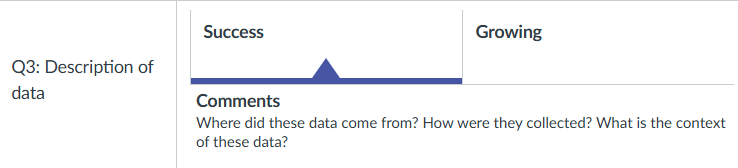

Lab 3 Grading

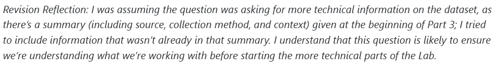

Lab 3 Question 3 Revision

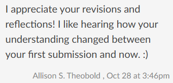

Lab 3 Canvas Comment

## Extending My Thinking

I’ve tried to experiment more with adding more to my labs than just the information necessary to answer each question. For example, I’ve started adding code comments (Lab 2), which is something I’ve never ever done in any programming course before. I’ve also been experimenting with aesthetics (Lab 5) that makes the html document a bit more visually appealing than the default layout - something I’ve also never cared to do in any other programming course. For the original lab 8, I had tried to style all my tables using kable() from the knitr package (for some reason it didn’t work with Q4 and crashed when I tried to use it for the really big table from Q2).

## Peer Support & Collaboration

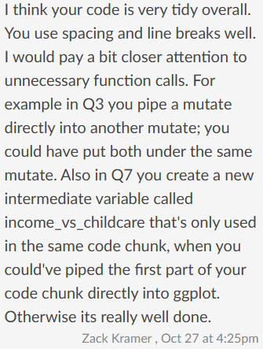

Lab 4 peer review

Discord feedback:

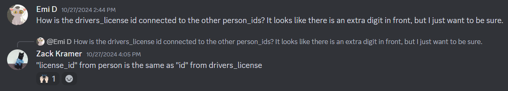

Lab 5 Discord screenshot

I was paired with Daniel for most of the pair programming activities, and I think we’ve learned to work well together. For the first activity it was a little slow and difficult to share the weight of the assignment (I find it easier to code alone), but we’ve discovered eachother’s strengths and weaknesses and have been able to finish each activity pretty efficiently. I paired up with Zhi He for the later activities and discovered that he’s a much different collaborator, definitely someone that would rather work alone. I found that I had to be a bit more forward and faster with my ideas to be able to contribute effectively. By our last activity we had a good dynamic and finished really quickly.